# insurance_costs_analysis

Ida Claesson

2026-04-26

## Inläsning av data

```r
library(tidyverse)
library(skimr)
library(patchwork)

insurance_costs_raw <- read_csv("data/insurance_costs.csv")
# Översikt över data
glimpse(insurance_costs_raw)
```

```
## Rows: 1,100
## Columns: 14
## $ customer_id       <chr> "C100000", "C100001", "C100002", "C100003", "C100004", "C100005", "C100006", "C100007", "C100008", "C100009", "C100010", "C100011", "C100012", "C100013", "C100014", "C10001~
## $ age               <dbl> 48, 40, 50, 62, 39, 39, 63, 52, 36, 49, 36, 36, 45, 18, 20, 35, 29, 46, 30, 24, 61, 39, 43, 23, 35, 43, 27, 47, 34, 38, 34, 66, 42, 28, 53, 26, 45, 18, 25, 45, 52, 44, 40, ~
## $ sex               <chr> "female", "male", "female", "male", "female", "female", "female", "male", "female", "male", "male", "female", "male", "female", "male", "female", "male", "male", "male", "m~
## $ region            <chr> "east", "west", "south", "north", "east", "west", "east", "north", "east", "west", "east", "west", "west", "east", "north", "south", "north", "south", "south", "north", "so~
## $ bmi               <dbl> 24.8, 29.5, 18.3, 25.5, 27.3, 23.3, 23.9, 24.8, 28.6, 26.9, 17.2, 17.8, 24.9, 28.8, 17.0, 25.0, NA, 33.9, 25.4, 28.7, 28.7, 17.8, 31.0, 27.9, 29.6, 44.0, 17.7, NA, 26.0, 28~
## $ children          <dbl> 0, 1, 2, 5, 2, 4, 3, 2, 0, 2, 2, 2, 1, 1, 1, 1, 0, 3, 0, 0, 1, 2, 1, 0, 2, 1, 4, 4, 1, 1, 2, 0, 1, 1, 4, 0, 2, 3, 1, 0, 5, 1, 2, 0, 1, 1, 0, 0, 3, 0, 0, 1, 3, 0, 2, 0, 0, 0~
## $ smoker            <chr> "no", "no", "no", "yes", "no", "no", "no", "no", "no", "yes", "no", "no", "no", "no", "no", "yes", "no", "no", "no", "no", "no", "no", "no", "no", "no", "yes", "no", "no", ~
## $ chronic_condition <chr> "no", "no", "no", "no", "no", "no", "no", "no", "yes", "no", "no", "yes", "no", "no", "no", "no", "no", "no", "no", "no", "no", "no", "yes", "yes", "no", "no", "no", "yes",~
## $ exercise_level    <chr> "high", "medium", "high", "medium", "medium", "high", "high", "medium", "low", "medium", "high", "high", "high", "low", "medium", "medium", "high", "low", "high", "medium",~
## $ plan_type         <chr> "basic", "basic", "standard", "basic", "basic", "standard", "basic", "basic", "basic", "standard", "standard", "basic", "premium", "standard", "basic", "basic", "standard",~
## $ prior_accidents   <dbl> 0, 0, 0, 0, 0, 0, 0, 0, 0, 1, 0, 1, 0, 0, 0, 0, 0, 0, 0, 0, 0, 1, 1, 1, 0, 0, 0, 1, 1, 0, 0, 0, 0, 3, 0, 0, 0, 1, 0, 0, 0, 0, 1, 0, 0, 0, 0, 0, 1, 0, 0, 0, 0, 0, 0, 0, 1, 0~
## $ prior_claims      <dbl> 0, 1, 0, 0, 1, 0, 0, 0, 1, 0, 0, 1, 0, 1, 3, 0, 0, 0, 0, 1, 1, 0, 0, 0, 0, 0, 0, 0, 0, 0, 0, 0, 0, 1, 0, 0, 0, 2, 0, 0, 0, 1, 0, 1, 0, 0, 1, 3, 0, 0, 0, 1, 0, 0, 0, 0, 0, 0~
## $ annual_checkups   <dbl> 1, 4, 3, NA, 0, 2, 1, 2, 3, 2, 3, 3, 4, 4, 2, 1, 2, 1, 3, 2, 1, 1, 2, 4, 2, 3, 2, 3, 2, 3, 0, 2, 2, 1, 4, 1, 1, 2, 3, 2, 3, 3, 1, 2, 2, 3, 0, 2, 3, 2, 2, 2, 1, 2, 2, 4, 1, ~
## $ charges           <dbl> 6439.10, 8274.06, 5190.99, 14500.35, 6534.40, 8026.39, 8770.46, 6926.29, 14105.25, 11702.80, 6429.21, 12158.24, 8101.27, 4971.48, 10151.02, 14385.41, 5028.62, 9154.14, 8088~
```

```r
skim_without_charts(insurance_costs_raw)
```

Data summary

| Name | insurance_costs_raw |
| --- | --- |
| Number of rows | 1100 |
| Number of columns | 14 |
| _______________________ |  |
| Column type frequency: |  |
| character | 7 |
| numeric | 7 |
| ________________________ |  |
| Group variables | None |

**Variable type: character**

| skim_variable | n_missing | complete_rate | min | max | empty | n_unique | whitespace |
| --- | --- | --- | --- | --- | --- | --- | --- |
| customer_id | 0 | 1.00 | 7 | 7 | 0 | 1100 | 0 |
| sex | 0 | 1.00 | 4 | 6 | 0 | 2 | 0 |
| region | 0 | 1.00 | 4 | 5 | 0 | 6 | 0 |
| smoker | 0 | 1.00 | 2 | 3 | 0 | 3 | 0 |
| chronic_condition | 0 | 1.00 | 2 | 3 | 0 | 2 | 0 |
| exercise_level | 22 | 0.98 | 3 | 6 | 0 | 3 | 0 |
| plan_type | 0 | 1.00 | 5 | 8 | 0 | 5 | 0 |

**Variable type: numeric**

| skim_variable | n_missing | complete_rate | mean | sd | p0 | p25 | p50 | p75 | p100 |
| --- | --- | --- | --- | --- | --- | --- | --- | --- | --- |
| age | 0 | 1.00 | 42.51 | 12.37 | 18.00 | 34.00 | 42.50 | 51.00 | 75.00 |
| bmi | 28 | 0.97 | 27.43 | 4.59 | 17.00 | 24.30 | 27.50 | 30.60 | 44.00 |
| children | 0 | 1.00 | 1.57 | 1.47 | 0.00 | 0.00 | 1.00 | 3.00 | 5.00 |
| prior_accidents | 0 | 1.00 | 0.24 | 0.50 | 0.00 | 0.00 | 0.00 | 0.00 | 3.00 |
| prior_claims | 0 | 1.00 | 0.27 | 0.53 | 0.00 | 0.00 | 0.00 | 0.00 | 3.00 |
| annual_checkups | 20 | 0.98 | 2.09 | 1.16 | 0.00 | 1.00 | 2.00 | 3.00 | 4.00 |
| charges | 0 | 1.00 | 10060.49 | 4574.45 | 1203.51 | 6836.95 | 9124.31 | 12710.08 | 32559.28 |

```r
# Kontrollera outliers
insurance_costs_raw %>%
  arrange(desc(charges)) %>%
  select(age, bmi, smoker, charges) %>%
  head(10)
```

```
## # A tibble: 10 x 4
##      age   bmi smoker charges
##    <dbl> <dbl> <chr>    <dbl>
##  1    26  31.3 yes     32559.
##  2    64  22.1 no      27337.
##  3    48  39   yes     26575.
##  4    47  32.2 yes     24986.
##  5    63  30.4 yes     24735.
##  6    44  33.2 yes     24718.
##  7    75  25.9 yes     24655.
##  8    74  23.9 yes     24565.
##  9    66  33.5 yes     24104.
## 10    67  33.9 yes     23932
```

```r
# Kategoriska variabler
insurance_costs_raw %>% distinct(sex)
```

```
## # A tibble: 2 x 1
##   sex
##   <chr>
## 1 female
## 2 male
```

```r
insurance_costs_raw %>% distinct(region)
```

```
## # A tibble: 6 x 1
##   region
##   <chr>
## 1 east
## 2 west
## 3 south
## 4 north
## 5 North
## 6 South
```

```r
insurance_costs_raw %>% distinct(smoker)
```

```
## # A tibble: 3 x 1
##   smoker
##   <chr>
## 1 no
## 2 yes
## 3 Yes
```

```r
insurance_costs_raw %>% distinct(chronic_condition)
```

```
## # A tibble: 2 x 1
##   chronic_condition
##   <chr>
## 1 no
## 2 yes
```

```r
insurance_costs_raw %>% distinct(exercise_level)
```

```
## # A tibble: 4 x 1
##   exercise_level
##   <chr>
## 1 high
## 2 medium
## 3 low
## 4 <NA>
```

```r
insurance_costs_raw %>% distinct(plan_type)
```

```
## # A tibble: 5 x 1
##   plan_type
##   <chr>
## 1 basic
## 2 standard
## 3 premium
## 4 Premium
## 5 Standard
```

```r
insurance_costs_raw %>% count(sex, sort = TRUE)
```

```
## # A tibble: 2 x 2
##   sex        n
##   <chr>  <int>
## 1 female   551
## 2 male     549
```

```r
insurance_costs_raw %>% count(region, sort = TRUE)
```

```
## # A tibble: 6 x 2
##   region     n
##   <chr>  <int>
## 1 south    315
## 2 west     264
## 3 north    255
## 4 east     253
## 5 North      8
## 6 South      5
```

```r
insurance_costs_raw %>% count(smoker, sort = TRUE)
```

```
## # A tibble: 3 x 2
##   smoker     n
##   <chr>  <int>
## 1 no       896
## 2 yes      200
## 3 Yes        4
```

```r
insurance_costs_raw %>% count(plan_type, sort = TRUE)
```

```
## # A tibble: 5 x 2
##   plan_type     n
##   <chr>     <int>
## 1 standard    549
## 2 basic       339
## 3 premium     201
## 4 Premium       7
## 5 Standard      4
```

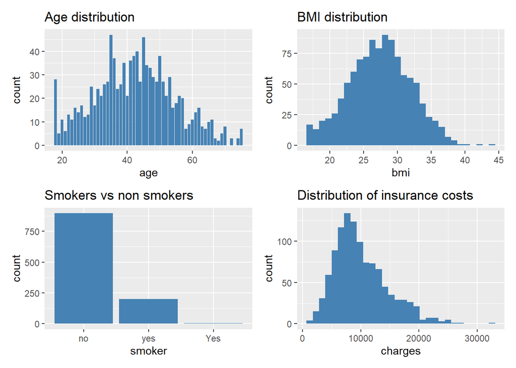

```r
p1 <- ggplot(insurance_costs_raw, aes(x = age)) +
  geom_bar(fill = "steelblue") +
  labs(title = "Age distribution")

p2 <- ggplot(insurance_costs_raw, aes(x = bmi)) +
  geom_histogram(fill = "steelblue") +
  labs(title = "BMI distribution")

p3 <- ggplot(insurance_costs_raw, aes(x = smoker)) +
  geom_bar(fill = "steelblue") +
  labs(title = "Smokers vs non smokers")

p4 <- ggplot(insurance_costs_raw, aes(x = charges)) +
  geom_histogram(fill = "steelblue") +
  labs(title = "Distribution of insurance costs")

p1 + p2 + p3 + p4
```

Viktiga datatyper: - age, bmi, children, smoker, chronic_condition, charges

- sex, region, smoker, plan_type, chronic_condition, exercise_level -> faktorer
- age, bmi, children, prior_accidents, prior_claims, annual_checkups charges -> numeriska

# Datastädning

```r
insurance_costs_raw <- read_csv("data/insurance_costs.csv")
insurance_costs_clean <- insurance_costs_raw

names(insurance_costs_clean)
```

```
##  [1] "customer_id"       "age"               "sex"               "region"            "bmi"               "children"          "smoker"            "chronic_condition" "exercise_level"
## [10] "plan_type"         "prior_accidents"   "prior_claims"      "annual_checkups"   "charges"
```

```r
colSums(is.na(insurance_costs_clean))
```

```
##       customer_id               age               sex            region               bmi          children            smoker chronic_condition    exercise_level         plan_type   prior_accidents
##                 0                 0                 0                 0                28                 0                 0                 0                22                 0                 0
##      prior_claims   annual_checkups           charges
##                 0                20                 0
```

```r
insurance_costs_clean <- insurance_costs_clean %>%
  mutate(
    region = str_to_lower(region),
    smoker = str_to_lower(smoker),
    plan_type = str_to_lower(plan_type)
  )

# Ändrar datatyper
insurance_costs_clean <- insurance_costs_clean %>%
  mutate(
    sex = as.factor(sex),
    smoker = as.factor(smoker),
    region = as.factor(region),
    plan_type = as.factor(plan_type),
    chronic_condition = as.factor(chronic_condition),
    exercise_level = as.factor(exercise_level)
  )






# Skapar nya variabler
insurance_costs_clean <- insurance_costs_clean %>%
  mutate(
    bmi_category = case_when(
      bmi < 18.5 ~ "Underweight",
      bmi < 25 ~ "Normal",
      bmi < 30 ~ "Overweight",
      TRUE ~ "Obese"
    )
  )

insurance_costs_clean <- insurance_costs_clean %>%
  mutate(
    age_group = case_when(
      age < 30 ~ "Young",
      age < 50 ~ "Middle",
      TRUE ~ "Older"
    )
  )

insurance_costs_clean <- insurance_costs_clean %>%
  mutate(
    risk_score = prior_accidents + prior_claims
  )



glimpse(insurance_costs_clean)
```

```
## Rows: 1,100
## Columns: 17
## $ customer_id       <chr> "C100000", "C100001", "C100002", "C100003", "C100004", "C100005", "C100006", "C100007", "C100008", "C100009", "C100010", "C100011", "C100012", "C100013", "C100014", "C10001~
## $ age               <dbl> 48, 40, 50, 62, 39, 39, 63, 52, 36, 49, 36, 36, 45, 18, 20, 35, 29, 46, 30, 24, 61, 39, 43, 23, 35, 43, 27, 47, 34, 38, 34, 66, 42, 28, 53, 26, 45, 18, 25, 45, 52, 44, 40, ~
## $ sex               <fct> female, male, female, male, female, female, female, male, female, male, male, female, male, female, male, female, male, male, male, male, female, male, male, male, female, ~
## $ region            <fct> east, west, south, north, east, west, east, north, east, west, east, west, west, east, north, south, north, south, south, north, south, north, west, west, north, west, sout~
## $ bmi               <dbl> 24.8, 29.5, 18.3, 25.5, 27.3, 23.3, 23.9, 24.8, 28.6, 26.9, 17.2, 17.8, 24.9, 28.8, 17.0, 25.0, NA, 33.9, 25.4, 28.7, 28.7, 17.8, 31.0, 27.9, 29.6, 44.0, 17.7, NA, 26.0, 28~
## $ children          <dbl> 0, 1, 2, 5, 2, 4, 3, 2, 0, 2, 2, 2, 1, 1, 1, 1, 0, 3, 0, 0, 1, 2, 1, 0, 2, 1, 4, 4, 1, 1, 2, 0, 1, 1, 4, 0, 2, 3, 1, 0, 5, 1, 2, 0, 1, 1, 0, 0, 3, 0, 0, 1, 3, 0, 2, 0, 0, 0~
## $ smoker            <fct> no, no, no, yes, no, no, no, no, no, yes, no, no, no, no, no, yes, no, no, no, no, no, no, no, no, no, yes, no, no, no, yes, no, no, no, yes, no, no, no, no, no, yes, no, n~
## $ chronic_condition <fct> no, no, no, no, no, no, no, no, yes, no, no, yes, no, no, no, no, no, no, no, no, no, no, yes, yes, no, no, no, yes, no, yes, no, yes, yes, no, no, no, no, no, no, yes, no,~
## $ exercise_level    <fct> high, medium, high, medium, medium, high, high, medium, low, medium, high, high, high, low, medium, medium, high, low, high, medium, low, medium, medium, medium, low, low, ~
## $ plan_type         <fct> basic, basic, standard, basic, basic, standard, basic, basic, basic, standard, standard, basic, premium, standard, basic, basic, standard, standard, basic, basic, premium, ~
## $ prior_accidents   <dbl> 0, 0, 0, 0, 0, 0, 0, 0, 0, 1, 0, 1, 0, 0, 0, 0, 0, 0, 0, 0, 0, 1, 1, 1, 0, 0, 0, 1, 1, 0, 0, 0, 0, 3, 0, 0, 0, 1, 0, 0, 0, 0, 1, 0, 0, 0, 0, 0, 1, 0, 0, 0, 0, 0, 0, 0, 1, 0~
## $ prior_claims      <dbl> 0, 1, 0, 0, 1, 0, 0, 0, 1, 0, 0, 1, 0, 1, 3, 0, 0, 0, 0, 1, 1, 0, 0, 0, 0, 0, 0, 0, 0, 0, 0, 0, 0, 1, 0, 0, 0, 2, 0, 0, 0, 1, 0, 1, 0, 0, 1, 3, 0, 0, 0, 1, 0, 0, 0, 0, 0, 0~
## $ annual_checkups   <dbl> 1, 4, 3, NA, 0, 2, 1, 2, 3, 2, 3, 3, 4, 4, 2, 1, 2, 1, 3, 2, 1, 1, 2, 4, 2, 3, 2, 3, 2, 3, 0, 2, 2, 1, 4, 1, 1, 2, 3, 2, 3, 3, 1, 2, 2, 3, 0, 2, 3, 2, 2, 2, 1, 2, 2, 4, 1, ~
## $ charges           <dbl> 6439.10, 8274.06, 5190.99, 14500.35, 6534.40, 8026.39, 8770.46, 6926.29, 14105.25, 11702.80, 6429.21, 12158.24, 8101.27, 4971.48, 10151.02, 14385.41, 5028.62, 9154.14, 8088~
## $ bmi_category      <chr> "Normal", "Overweight", "Underweight", "Overweight", "Overweight", "Normal", "Normal", "Normal", "Overweight", "Overweight", "Underweight", "Underweight", "Normal", "Overwe~
## $ age_group         <chr> "Middle", "Middle", "Older", "Older", "Middle", "Middle", "Older", "Older", "Middle", "Middle", "Middle", "Middle", "Middle", "Young", "Young", "Middle", "Young", "Middle",~
## $ risk_score        <dbl> 0, 1, 0, 0, 1, 0, 0, 0, 1, 1, 0, 2, 0, 1, 3, 0, 0, 0, 0, 1, 1, 1, 1, 1, 0, 0, 0, 1, 1, 0, 0, 0, 0, 4, 0, 0, 0, 3, 0, 0, 0, 1, 1, 1, 0, 0, 1, 3, 1, 0, 0, 1, 0, 0, 0, 0, 1, 0~
```

Saknade värden: - bmi hade 28 saknade värden - annual_checkups hade 20 saknade värden - exercise_level hade 22 saknade värden - Saknade värden är relativt få så de lämnas och hanteras med na.rm = TRUE

# Analys och figurer

```r
source("scripts/stadning.R")
```

```
## Rows: 1,100
## Columns: 17
## $ customer_id       <chr> "C100000", "C100001", "C100002", "C100003", "C100004", "C100005", "C100006", "C100007", "C100008", "C100009", "C100010", "C100011", "C100012", "C100013", "C100014", "C10001~
## $ age               <dbl> 48, 40, 50, 62, 39, 39, 63, 52, 36, 49, 36, 36, 45, 18, 20, 35, 29, 46, 30, 24, 61, 39, 43, 23, 35, 43, 27, 47, 34, 38, 34, 66, 42, 28, 53, 26, 45, 18, 25, 45, 52, 44, 40, ~
## $ sex               <fct> female, male, female, male, female, female, female, male, female, male, male, female, male, female, male, female, male, male, male, male, female, male, male, male, female, ~
## $ region            <fct> east, west, south, north, east, west, east, north, east, west, east, west, west, east, north, south, north, south, south, north, south, north, west, west, north, west, sout~
## $ bmi               <dbl> 24.8, 29.5, 18.3, 25.5, 27.3, 23.3, 23.9, 24.8, 28.6, 26.9, 17.2, 17.8, 24.9, 28.8, 17.0, 25.0, NA, 33.9, 25.4, 28.7, 28.7, 17.8, 31.0, 27.9, 29.6, 44.0, 17.7, NA, 26.0, 28~
## $ children          <dbl> 0, 1, 2, 5, 2, 4, 3, 2, 0, 2, 2, 2, 1, 1, 1, 1, 0, 3, 0, 0, 1, 2, 1, 0, 2, 1, 4, 4, 1, 1, 2, 0, 1, 1, 4, 0, 2, 3, 1, 0, 5, 1, 2, 0, 1, 1, 0, 0, 3, 0, 0, 1, 3, 0, 2, 0, 0, 0~
## $ smoker            <fct> no, no, no, yes, no, no, no, no, no, yes, no, no, no, no, no, yes, no, no, no, no, no, no, no, no, no, yes, no, no, no, yes, no, no, no, yes, no, no, no, no, no, yes, no, n~
## $ chronic_condition <fct> no, no, no, no, no, no, no, no, yes, no, no, yes, no, no, no, no, no, no, no, no, no, no, yes, yes, no, no, no, yes, no, yes, no, yes, yes, no, no, no, no, no, no, yes, no,~
## $ exercise_level    <fct> high, medium, high, medium, medium, high, high, medium, low, medium, high, high, high, low, medium, medium, high, low, high, medium, low, medium, medium, medium, low, low, ~
## $ plan_type         <fct> basic, basic, standard, basic, basic, standard, basic, basic, basic, standard, standard, basic, premium, standard, basic, basic, standard, standard, basic, basic, premium, ~
## $ prior_accidents   <dbl> 0, 0, 0, 0, 0, 0, 0, 0, 0, 1, 0, 1, 0, 0, 0, 0, 0, 0, 0, 0, 0, 1, 1, 1, 0, 0, 0, 1, 1, 0, 0, 0, 0, 3, 0, 0, 0, 1, 0, 0, 0, 0, 1, 0, 0, 0, 0, 0, 1, 0, 0, 0, 0, 0, 0, 0, 1, 0~
## $ prior_claims      <dbl> 0, 1, 0, 0, 1, 0, 0, 0, 1, 0, 0, 1, 0, 1, 3, 0, 0, 0, 0, 1, 1, 0, 0, 0, 0, 0, 0, 0, 0, 0, 0, 0, 0, 1, 0, 0, 0, 2, 0, 0, 0, 1, 0, 1, 0, 0, 1, 3, 0, 0, 0, 1, 0, 0, 0, 0, 0, 0~
## $ annual_checkups   <dbl> 1, 4, 3, NA, 0, 2, 1, 2, 3, 2, 3, 3, 4, 4, 2, 1, 2, 1, 3, 2, 1, 1, 2, 4, 2, 3, 2, 3, 2, 3, 0, 2, 2, 1, 4, 1, 1, 2, 3, 2, 3, 3, 1, 2, 2, 3, 0, 2, 3, 2, 2, 2, 1, 2, 2, 4, 1, ~
## $ charges           <dbl> 6439.10, 8274.06, 5190.99, 14500.35, 6534.40, 8026.39, 8770.46, 6926.29, 14105.25, 11702.80, 6429.21, 12158.24, 8101.27, 4971.48, 10151.02, 14385.41, 5028.62, 9154.14, 8088~
## $ bmi_category      <chr> "Normal", "Overweight", "Underweight", "Overweight", "Overweight", "Normal", "Normal", "Normal", "Overweight", "Overweight", "Underweight", "Underweight", "Normal", "Overwe~
## $ age_group         <chr> "Middle", "Middle", "Older", "Older", "Middle", "Middle", "Older", "Older", "Middle", "Middle", "Middle", "Middle", "Middle", "Young", "Young", "Middle", "Young", "Middle",~
## $ risk_score        <dbl> 0, 1, 0, 0, 1, 0, 0, 0, 1, 1, 0, 2, 0, 1, 3, 0, 0, 0, 0, 1, 1, 1, 1, 1, 0, 0, 0, 1, 1, 0, 0, 0, 0, 4, 0, 0, 0, 3, 0, 0, 0, 1, 1, 1, 0, 0, 1, 3, 1, 0, 0, 1, 0, 0, 0, 0, 1, 0~
```

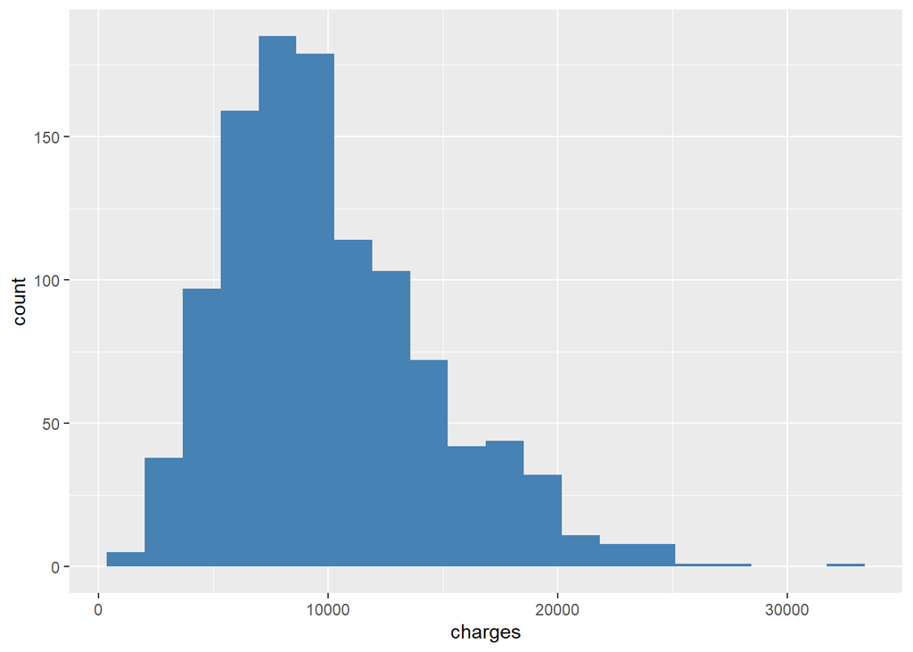

```r
# Fördelning av kostnaderna
p_cost_distribution <- ggplot(insurance_costs_clean, aes(x = charges)) +
  geom_histogram(fill = "steelblue", bins = 20)

p_cost_distribution
```

```r
# Histogramet visar att försäkringskostnaderna för de flesta ligger runt 10000kr, dock har en del kunder en högre kostnad.


# Samband mellan ålder och kostnad
insurance_costs_clean %>%
  summarise(correlation = cor(age, charges, use = "complete.obs"))
```

```
## # A tibble: 1 x 1
##   correlation
##         <dbl>
## 1       0.258
```

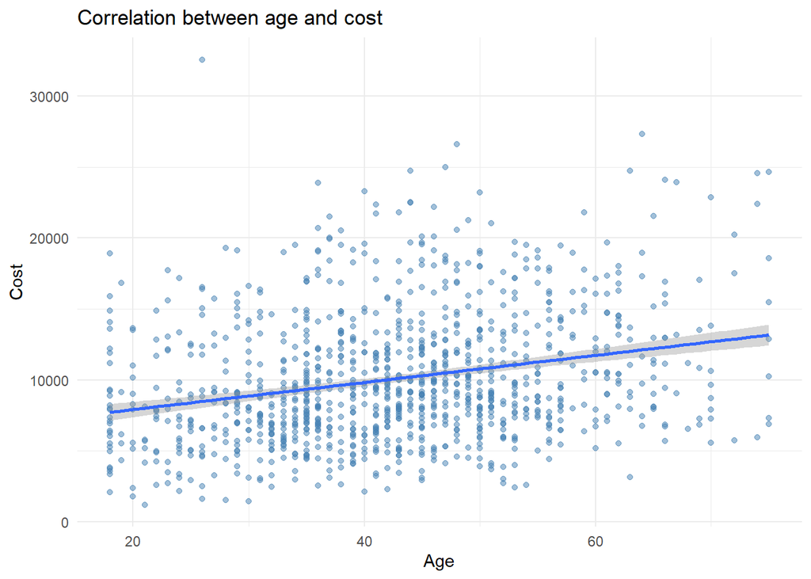

```r
p_age_charge <- ggplot(insurance_costs_clean, aes(x= age, y = charges)) +
  geom_point(alpha = 0.5, color = "steelblue") +
  geom_smooth(method = "lm", se = TRUE) +
  labs(
    title = "Correlation between age and cost",
    x = "Age",
    y = "Cost"
  ) +
  theme_minimal()

p_age_charge
```

```r
# Correlation = 0.258
# Finns ett positivt samband mellan ålder och kostnader, som visar att äldre har högre försäkringskostnader.


# Samband mellan BMI och kostnad
insurance_costs_clean %>%
  summarise(correlation = cor(bmi, charges, use = "complete.obs"))
```

```
## # A tibble: 1 x 1
##   correlation
##         <dbl>
## 1       0.152
```

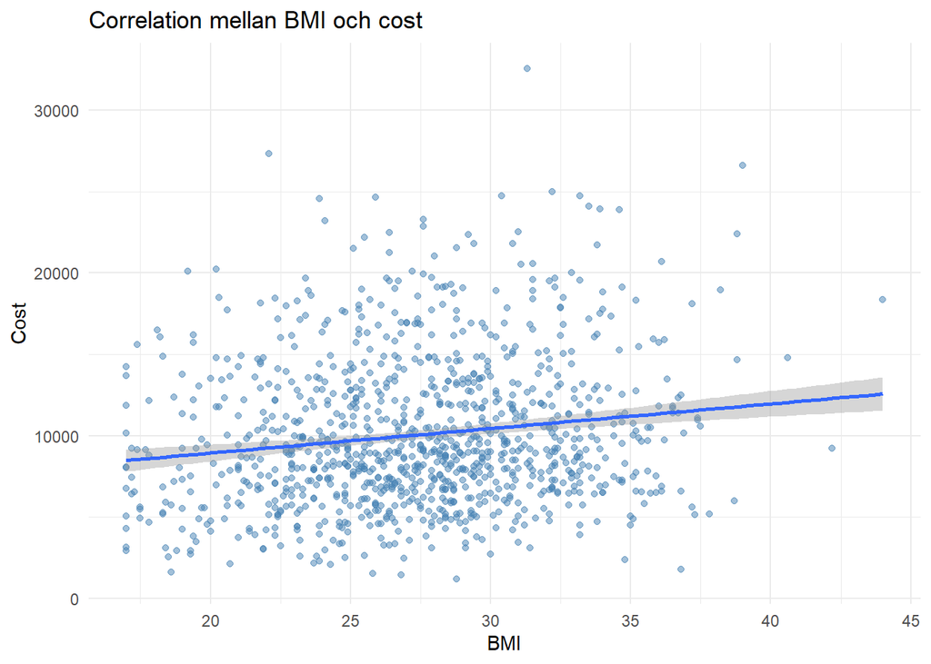

```r
p_bmi_charge <- ggplot(insurance_costs_clean, aes(x = bmi, y = charges)) +
  geom_point(alpha = 0.5, color = "steelblue") +
  geom_smooth(method = "lm", se = TRUE) +
  labs(
    title = "Correlation mellan BMI och cost",
    x = "BMI",
    y = "Cost"
  ) +
  theme_minimal()

p_bmi_charge
```